# R4DS_2E_numbers

Answer: I imagine cos, sin, tan will be there. When using autocomplete we see, cos, coth, sin, sinh, tan, and tanh. Although cosec, sec and cot aren’t there it doesn’t really matter as we can always define these on our own using the pre-existing base trigonometric functions. Angles are givin in radians according to documentation.

```r
sin(pi/2)
```

```
## [1] 1
```

```r
cos(pi)
```

```
## [1] -1
```

3. Currently dep_time and sched_dep_time are convenient to look at, but hard to compute with because they’re not really continuous numbers. You can see the basic problem by running the code below: there’s a gap between each hour.

flights |> filter(month == 1, day == 1) |> ggplot(aes(x = sched_dep_time, y = dep_delay)) + geom_point()

Convert them to a more truthful representation of time (either fractional hours or minutes since midnight).

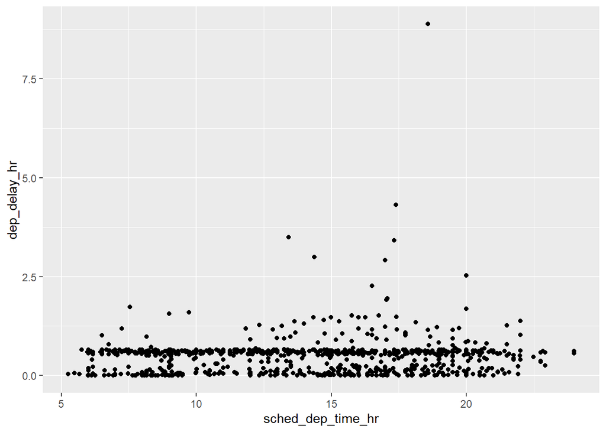

```r
View(flights)

flights |>
  mutate(
    sched_dep_time_hour = sched_dep_time %/% 100,
    sched_dep_time_min = sched_dep_time %% 100,
    sched_dep_time_hr = sched_dep_time_hour + (sched_dep_time_min / 60),
    dep_delay_hour = dep_delay %/% 100,
    dep_delay_min = dep_delay %% 100,
    dep_delay_hr = dep_delay_hour + (dep_delay_min / 60)
  ) |>
  filter(month == 1, day == 1) |>
  ggplot(aes(x = sched_dep_time_hr, y = dep_delay_hr)) +
  geom_point()
```

4. Round dep_time and arr_time to the nearest five minutes.

Answer: To round to something specific like “five minutes” rather than a set number of digits, we have to do some computation within the round function followed by the opposite computation outside of the function

```r
# Going to use a small sample of times instead
x <- c(517, 518, 521, 555, 558, 601, 622, 2326, 2328, 2325, 2359)
round(x / 5) * 5
```

```
##  [1]  515  520  520  555  560  600  620 2325 2330 2325 2360
```

```r
# 517/5 goes to 103.4 which is rounded to 103. Then multiplied by 5 we get 515 as required. The only issue currently is if we have times between *58-*59 which round to *60 which we don't want. We want to it round to (*+1)00

# Lets exclude this case by using an if_else statement. There is most likely a much more elegant, but more complicated way to solve this using modulo operator:
if_else((x %% 100) %in% c(58, 59), (x + 100) - (x %% 100), round(x / 5) * 5)
```

```
##  [1]  515  520  520  555  600  600  620 2325 2330 2325 2400
```

```r
flights |>
  mutate(
    arr_time = if_else((arr_time %% 100) %in% c(58, 59),
                       (arr_time + 100) - (arr_time %% 100),
                       round(arr_time / 5) * 5),
    dep_time = if_else((dep_time %% 100) %in% c(58, 59),
                       (dep_time + 100) - (dep_time %% 100),
                       round(dep_time / 5) * 5),
  )
```

```
## # A tibble: 336,776 × 19
##     year month   day dep_time sched_dep_time dep_delay arr_time sched_arr_time
##    <int> <int> <int>    <dbl>          <int>     <dbl>    <dbl>          <int>
##  1  2013     1     1      515            515         2      830            819
##  2  2013     1     1      535            529         4      850            830
##  3  2013     1     1      540            540         2      925            850
##  4  2013     1     1      545            545        -1     1005           1022
##  5  2013     1     1      555            600        -6      810            837
##  6  2013     1     1      555            558        -4      740            728
##  7  2013     1     1      555            600        -5      915            854
##  8  2013     1     1      555            600        -3      710            723
##  9  2013     1     1      555            600        -3      840            846
## 10  2013     1     1      600            600        -2      755            745
## # ℹ 336,766 more rows
## # ℹ 11 more variables: arr_delay <dbl>, carrier <chr>, flight <int>,
## #   tailnum <chr>, origin <chr>, dest <chr>, air_time <dbl>, distance <dbl>,
## #   hour <dbl>, minute <dbl>, time_hour <dttm>
```

## Transform - General transformations

1. Find the 10 most delayed flights using a ranking function. How do you want to handle ties? Carefully read the documentation for min_rank().

```r
x <- c(1, 2, 6, 3, 4, NA)
min_rank(x)
```

```
## [1]  1  2  5  3  4 NA
```

```
#> 1  2  5  3  4 NA
```

```r
min_rank(desc(x))
```

```
## [1]  5  4  1  3  2 NA
```

```
#> 5  4  1  3  2 NA
```

```r
flights |>
  mutate(rank = min_rank(desc(dep_delay))) |>
  arrange(rank) |>
  filter(rank %in% 1:10)
```

```
## # A tibble: 10 × 20
##     year month   day dep_time sched_dep_time dep_delay arr_time sched_arr_time
##    <int> <int> <int>    <int>          <int>     <dbl>    <int>          <int>
##  1  2013     1     9      641            900      1301     1242           1530
##  2  2013     6    15     1432           1935      1137     1607           2120
##  3  2013     1    10     1121           1635      1126     1239           1810
##  4  2013     9    20     1139           1845      1014     1457           2210
##  5  2013     7    22      845           1600      1005     1044           1815
##  6  2013     4    10     1100           1900       960     1342           2211
##  7  2013     3    17     2321            810       911      135           1020
##  8  2013     6    27      959           1900       899     1236           2226
##  9  2013     7    22     2257            759       898      121           1026
## 10  2013    12     5      756           1700       896     1058           2020
## # ℹ 12 more variables: arr_delay <dbl>, carrier <chr>, flight <int>,
## #   tailnum <chr>, origin <chr>, dest <chr>, air_time <dbl>, distance <dbl>,
## #   hour <dbl>, minute <dbl>, time_hour <dttm>, rank <int>
```

```r
# We can handle ties by instead using `row_number` so that way if we had two flights with same dep_delay value, the flight that appeared first via row_number will be chosen over the second one.
```

2. Which plane (tailnum) has the worst on-time record?

```r
# To calculate how "on-time" a plane is, we could do this multiple different ways. For example:
```

```
#> 1. We simply calculate the sum of arr_delay for each plane
#> 2. Or we can calculate the average arr_delay for each plane to account for the total number of flights of each plane
#> Also note that a plane might only take a very bad route where all other planes also have a large delay, so in this case its not really the planes fault for a bad on-time record, its the destination
```

```r
flights |>
  group_by(tailnum) |>
  summarize(on_time = sum(arr_delay, na.rm = TRUE)) |>
  arrange(desc(on_time))
```

```
## # A tibble: 4,044 × 2
##    tailnum on_time
##    <chr>     <dbl>
##  1 N15910     7317
##  2 N15980     7134
##  3 N16919     6904
##  4 N228JB     6778
##  5 N14998     6087
##  6 N192JB     5810
##  7 N292JB     5804
##  8 N12921     5788
##  9 N13958     5620
## 10 N10575     5566
## # ℹ 4,034 more rows
```

```r
# tailnum N15910 has the worst on_time record

flights |>
  group_by(tailnum) |>
  summarize(on_time = mean(arr_delay, na.rm = TRUE)) |>
  arrange(desc(on_time))
```

```
## # A tibble: 4,044 × 2
##    tailnum on_time
##    <chr>     <dbl>
##  1 N844MH     320
##  2 N911DA     294
##  3 N922EV     276
##  4 N587NW     264
##  5 N851NW     219
##  6 N928DN     201
##  7 N7715E     188
##  8 N654UA     185
##  9 N665MQ     175.
## 10 N427SW     157
## # ℹ 4,034 more rows
```

```r
# Using second method, tailnum N844MH has the worst on_time record
```

3. What time of day should you fly if you want to avoid delays as much as possible?

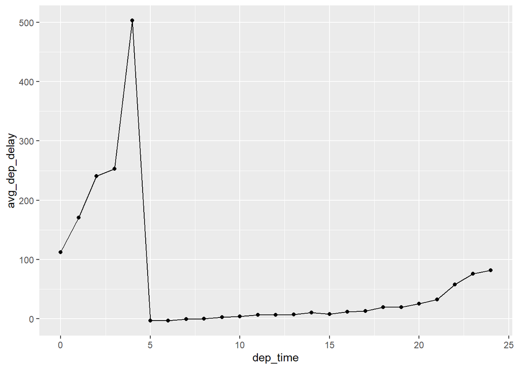

```r
# We should focus on departure times as this is something we have more control over avoiding delays if we are a customer.
flights |>
  mutate(dep_time = round((dep_time %/% 100) + ((dep_time %% 100) / 60), 0)) |>
  group_by(dep_time) |>
  mutate(avg_dep_delay = mean(dep_delay, na.rm = TRUE)) |>
  ggplot(aes(x = dep_time, y = avg_dep_delay)) +
  geom_line() +
  geom_point()
```

```r
# Best time to fly is in the very early hours of the morning around 5 when all the delay congestion from the previous day has dissipated.
```

4. What does flights |> group_by(dest) |> filter(row_number() < 4) do? What does flights |> group_by(dest) |> filter(row_number(dep_delay) < 4) do?

```r
flights |> group_by(dest) |> filter(row_number() < 4)
```

```
## # A tibble: 311 × 19
## # Groups:   dest [105]
##     year month   day dep_time sched_dep_time dep_delay arr_time sched_arr_time
##    <int> <int> <int>    <int>          <int>     <dbl>    <int>          <int>
##  1  2013     1     1      517            515         2      830            819
##  2  2013     1     1      533            529         4      850            830
##  3  2013     1     1      542            540         2      923            850
##  4  2013     1     1      544            545        -1     1004           1022
##  5  2013     1     1      554            600        -6      812            837
##  6  2013     1     1      554            558        -4      740            728
##  7  2013     1     1      555            600        -5      913            854
##  8  2013     1     1      557            600        -3      709            723
##  9  2013     1     1      557            600        -3      838            846
## 10  2013     1     1      558            600        -2      753            745
## # ℹ 301 more rows
## # ℹ 11 more variables: arr_delay <dbl>, carrier <chr>, flight <int>,
## #   tailnum <chr>, origin <chr>, dest <chr>, air_time <dbl>, distance <dbl>,
## #   hour <dbl>, minute <dbl>, time_hour <dttm>
```

```r
# First groups by destination and then filter to the first three row numbers where these destinations appear. For example if dest is ATL, then the first three appearences of this destination within the dataset will be filtered based off of this. ATL appears once at row 5, a second time at row 19 and a third time at row 24 in the original dataset. These rows will be pulled.

flights |> group_by(dest) |> filter(row_number(dep_delay) < 4)
```

```
## # A tibble: 310 × 19
## # Groups:   dest [104]
##     year month   day dep_time sched_dep_time dep_delay arr_time sched_arr_time
##    <int> <int> <int>    <int>          <int>     <dbl>    <int>          <int>
##  1  2013     1     1      848            851        -3     1155           1136
##  2  2013     1     1      946            959       -13     1146           1202
##  3  2013     1     4     2140           2159       -19     2241           2316
##  4  2013     1     5      859            901        -2     1144           1201
##  5  2013     1     5     2143           2159       -16     2257           2315
##  6  2013     1     7     1801           1810        -9     2116           2142
##  7  2013     1     7     2013           2030       -17     2150           2206
##  8  2013     1     8      735            750       -15      912            940
##  9  2013     1     9     1847           1858       -11     2024           2055
## 10  2013     1    10      810            827       -17      955           1031
## # ℹ 300 more rows
## # ℹ 11 more variables: arr_delay <dbl>, carrier <chr>, flight <int>,
## #   tailnum <chr>, origin <chr>, dest <chr>, air_time <dbl>, distance <dbl>,
## #   hour <dbl>, minute <dbl>, time_hour <dttm>
```

```r
# Similar to above. We just have an added caviat that `row_number` is now based off `dep_delay`. Take the destination "AVL" for example. The first three rows with the lowest values in dep_delay (i.e. those with the smallest departure "delay") will be selected. This is similar for all the other destinations. Look at the added code below and run it piecemeal to see what `row_number` is doing.

flights |> group_by(dest) |> mutate(row_number(dep_delay) < 4)
```

```
## # A tibble: 336,776 × 20
## # Groups:   dest [105]
##     year month   day dep_time sched_dep_time dep_delay arr_time sched_arr_time
##    <int> <int> <int>    <int>          <int>     <dbl>    <int>          <int>
##  1  2013     1     1      517            515         2      830            819
##  2  2013     1     1      533            529         4      850            830
##  3  2013     1     1      542            540         2      923            850
##  4  2013     1     1      544            545        -1     1004           1022
##  5  2013     1     1      554            600        -6      812            837
##  6  2013     1     1      554            558        -4      740            728
##  7  2013     1     1      555            600        -5      913            854
##  8  2013     1     1      557            600        -3      709            723
##  9  2013     1     1      557            600        -3      838            846
## 10  2013     1     1      558            600        -2      753            745
## # ℹ 336,766 more rows
## # ℹ 12 more variables: arr_delay <dbl>, carrier <chr>, flight <int>,
## #   tailnum <chr>, origin <chr>, dest <chr>, air_time <dbl>, distance <dbl>,
## #   hour <dbl>, minute <dbl>, time_hour <dttm>,
## #   `row_number(dep_delay) < 4` <lgl>
```

```r
flights |>
  group_by(dest) |>
  mutate(rnum = row_number(dep_delay)) |>
  filter(dest == "AVL") |>
  arrange(rnum) |>
  relocate(dep_delay, dest, rnum)
```

```
## # A tibble: 275 × 20
## # Groups:   dest [1]
##    dep_delay dest   rnum  year month   day dep_time sched_dep_time arr_time
##        <dbl> <chr> <int> <int> <int> <int>    <int>          <int>    <int>
##  1       -13 AVL       1  2013     1     1      946            959     1146
##  2       -12 AVL       2  2013     8    31     1548           1600     1744
##  3       -11 AVL       3  2013     5    12      924            935     1127
##  4       -11 AVL       4  2013     8     6      824            835     1018
##  5       -11 AVL       5  2013     9     7     1548           1559     1726
##  6       -10 AVL       6  2013    10    31     1628           1638     1831
##  7       -10 AVL       7  2013     5    11      822            832     1030
##  8       -10 AVL       8  2013     5    18      822            832     1014
##  9       -10 AVL       9  2013     5    19      827            837     1015
## 10       -10 AVL      10  2013     5    19      925            935     1122
## # ℹ 265 more rows
## # ℹ 11 more variables: sched_arr_time <int>, arr_delay <dbl>, carrier <chr>,
## #   flight <int>, tailnum <chr>, origin <chr>, air_time <dbl>, distance <dbl>,
## #   hour <dbl>, minute <dbl>, time_hour <dttm>
```

5. For each destination, compute the total minutes of delay. For each flight, compute the proportion of the total delay for its destination.

```r
# arr_delay should only matter in this context

flights |>
  group_by(dest) |>
  mutate(total_arr_delay = sum(arr_delay, na.rm = TRUE))
```

```
## # A tibble: 336,776 × 20
## # Groups:   dest [105]
##     year month   day dep_time sched_dep_time dep_delay arr_time sched_arr_time
##    <int> <int> <int>    <int>          <int>     <dbl>    <int>          <int>
##  1  2013     1     1      517            515         2      830            819
##  2  2013     1     1      533            529         4      850            830
##  3  2013     1     1      542            540         2      923            850
##  4  2013     1     1      544            545        -1     1004           1022
##  5  2013     1     1      554            600        -6      812            837
##  6  2013     1     1      554            558        -4      740            728
##  7  2013     1     1      555            600        -5      913            854
##  8  2013     1     1      557            600        -3      709            723
##  9  2013     1     1      557            600        -3      838            846
## 10  2013     1     1      558            600        -2      753            745
## # ℹ 336,766 more rows
## # ℹ 12 more variables: arr_delay <dbl>, carrier <chr>, flight <int>,
## #   tailnum <chr>, origin <chr>, dest <chr>, air_time <dbl>, distance <dbl>,
## #   hour <dbl>, minute <dbl>, time_hour <dttm>, total_arr_delay <dbl>
```

```r
# If we want to compute the proportion of the total delay for a flights destination, we will need to get the total air time for each flight.
flights |>
  filter(arr_delay >= 0) |> # Can't have a negative proportion, and we don't really need to consider flights that weren't actually delayed.
  mutate(arr_delay_prop = arr_delay / air_time)
```

```
## # A tibble: 138,413 × 20
##     year month   day dep_time sched_dep_time dep_delay arr_time sched_arr_time
##    <int> <int> <int>    <int>          <int>     <dbl>    <int>          <int>
##  1  2013     1     1      517            515         2      830            819
##  2  2013     1     1      533            529         4      850            830
##  3  2013     1     1      542            540         2      923            850
##  4  2013     1     1      554            558        -4      740            728
##  5  2013     1     1      555            600        -5      913            854
##  6  2013     1     1      558            600        -2      753            745
##  7  2013     1     1      558            600        -2      924            917
##  8  2013     1     1      559            600        -1      941            910
##  9  2013     1     1      600            600         0      837            825
## 10  2013     1     1      602            605        -3      821            805
## # ℹ 138,403 more rows
## # ℹ 12 more variables: arr_delay <dbl>, carrier <chr>, flight <int>,
## #   tailnum <chr>, origin <chr>, dest <chr>, air_time <dbl>, distance <dbl>,
## #   hour <dbl>, minute <dbl>, time_hour <dttm>, arr_delay_prop <dbl>
```

6. Delays are typically temporally correlated: even once the problem that caused the initial delay has been resolved, later flights are delayed to allow earlier flights to leave. Using lag(), explore how the average flight delay for an hour is related to the average delay for the previous hour.

```r
hr_delay_flights <- flights |>
  mutate(hour = dep_time %/% 100) |>
  group_by(year, month, day, hour) |>
  summarize(
    dep_delay = mean(dep_delay, na.rm = TRUE),
    n = n(),
    .groups = "drop"
  ) |>
  filter(n > 5) |>
# For some reason there are random missing values for some days during the late hours of the day. This is because dep_time == NA so I imagine they cancel alot of flights later on in the day to prevent congestion for the next day of flights. I will remove these for now as it'll be easier to see if previous delay times effect future delay times.
  filter(!is.na(hour))

# Another issue I see is now all hours aren't even consecutive. Take row 218, we have an hour of 0. The previous hour was 21 of the previous day, and the next hour is at 5. Take a look at the following code:

hr_delay_flights |>
  group_by(hour) |>
  summarize(
    n = n(),
    .groups = "drop"
  )
```

```
## # A tibble: 22 × 2
##     hour     n
##    <dbl> <int>
##  1     0    46
##  2     1    10
##  3     2     3
##  4     5   363
##  5     6   364
##  6     7   364
##  7     8   364
##  8     9   364
##  9    10   364
## 10    11   364
## # ℹ 12 more rows
```

```r
# hours 0-2 look like we should drop them but I'm not sure. Instead I'm going to look through the solution in `transform.Rmd`
```

```r
# This calculates the departure delay of the preceding flight from the same airport.
lagged_delays <- flights %>%
  arrange(origin, month, day, dep_time) %>%
  group_by(origin) %>%
  mutate(dep_delay_lag = lag(dep_delay)) %>%
  filter(!is.na(dep_delay), !is.na(dep_delay_lag))
```

This plots the relationship between the mean delay of a flight for all values of the previous flight. For delays less than two hours, the relationship between the delay of the preceding flight and the current flight is nearly a line. After that the relationship becomes more variable, as long-delayed flights are interspersed with flights leaving on-time. After about 8-hours, a delayed flight is likely to be followed by a flight leaving on time.

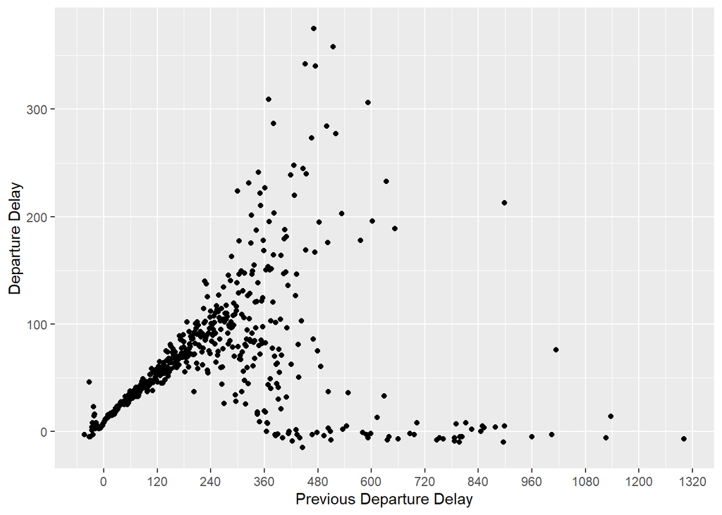

```r
lagged_delays %>%
  group_by(dep_delay_lag) %>%
  summarise(dep_delay_mean = mean(dep_delay)) %>%
  ggplot(aes(y = dep_delay_mean, x = dep_delay_lag)) +
  geom_point() +
  scale_x_continuous(breaks = seq(0, 1500, by = 120)) +
  labs(y = "Departure Delay", x = "Previous Departure Delay")
```

The above plot is for all three airport origins. When faceting them by origin the relationships all look very similar

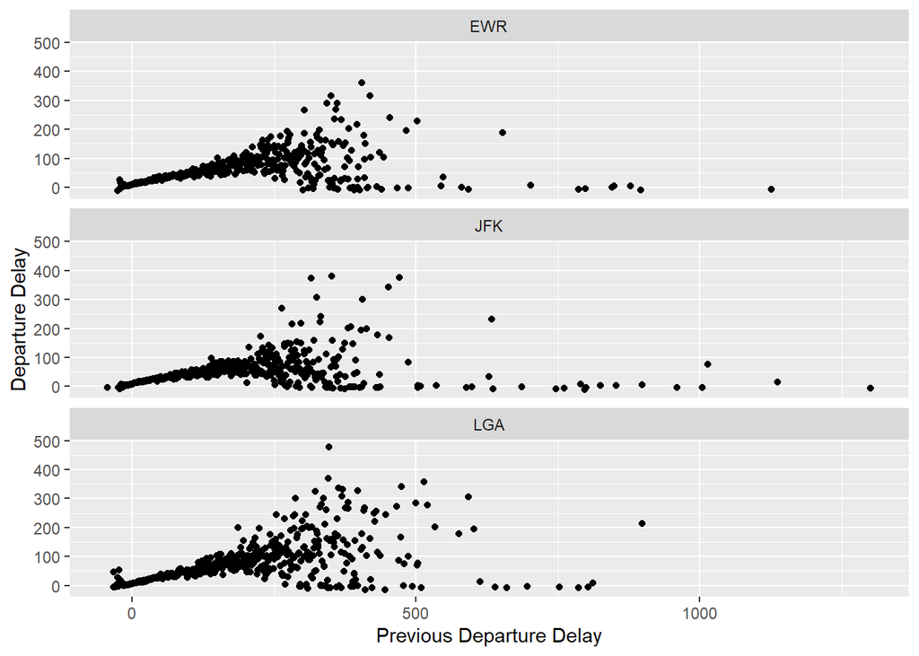

```r
lagged_delays %>%
  group_by(origin, dep_delay_lag) %>%
  summarise(dep_delay_mean = mean(dep_delay)) %>%
  ggplot(aes(y = dep_delay_mean, x = dep_delay_lag)) +
  geom_point() +
  facet_wrap(~ origin, ncol = 1) +
  labs(y = "Departure Delay", x = "Previous Departure Delay")
```

7. Look at each destination. Can you find flights that are suspiciously fast (i.e. flights that represent a potential data entry error)? Compute the air time of a flight relative to the shortest flight to that destination. Which flights were most delayed in the air?

```r
flights |>
  group_by(dest) |>
  summarize(
    air_time = air_time
  ) |>
  arrange(air_time)
```

```
## # A tibble: 336,776 × 2
## # Groups:   dest [105]
##    dest  air_time
##    <chr>    <dbl>
##  1 BDL         20
##  2 BDL         20
##  3 BDL         21
##  4 BDL         21
##  5 BDL         21
##  6 BDL         21
##  7 BDL         21
##  8 BDL         21
##  9 BDL         21
## 10 BDL         21
## # ℹ 336,766 more rows
```

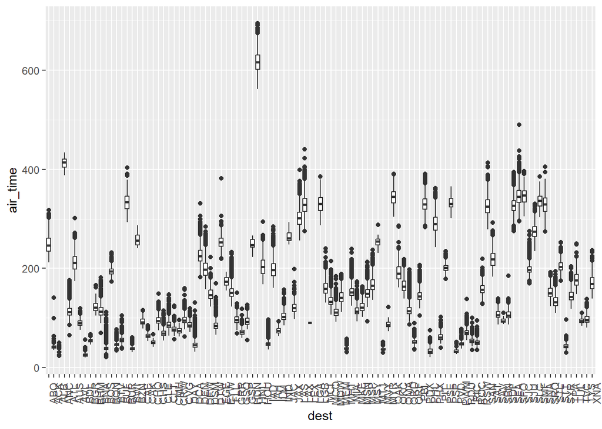

```r
# To see if an air_time of only 20 minutes is actually a data entry error we could look at the following: What is the distance between the origin and destination? How many other planes had a similarly low air_time? If only one plane had a much lower air_time then other planes then maybe we can argue this is a data entry error.

flights |>
  group_by(origin, dest, tailnum) |>
  ggplot(aes(y = air_time, x = dest)) +
  theme(axis.text.x = element_text(angle = 90)) +
  geom_boxplot()
```

```r
# I tried this way but its honestly pretty messy to find fast flights. Look at the standardization technique used in the community sol-n's in `transform.Rmd`
```

8. Find all destinations that are flown by at least two carriers. Use those destinations to come up with a relative ranking of the carriers based on their performance for the same destination.

```r
multiple_carriers <- flights |>
  group_by(dest, carrier) |>
  summarize() |>
  filter(table(dest) >= 2) |>
  ungroup()
unique(multiple_carriers$dest)
```

```
##  [1] "ATL" "AUS" "AVL" "BDL" "BGR" "BNA" "BOS" "BQN" "BTV" "BUF" "BWI" "CAE"
## [13] "CHS" "CLE" "CLT" "CMH" "CVG" "DAY" "DCA" "DEN" "DFW" "DSM" "DTW" "EGE"
## [25] "FLL" "GRR" "GSO" "GSP" "HNL" "HOU" "IAD" "IAH" "IND" "JAC" "JAX" "LAS"
## [37] "LAX" "MCI" "MCO" "MEM" "MHT" "MIA" "MKE" "MSN" "MSP" "MSY" "MVY" "OMA"
## [49] "ORD" "ORF" "PBI" "PDX" "PHL" "PHX" "PIT" "PWM" "RDU" "RIC" "ROC" "RSW"
## [61] "SAN" "SAT" "SDF" "SEA" "SFO" "SJC" "SJU" "SLC" "SRQ" "STL" "STT" "SYR"
## [73] "TPA" "TVC" "TYS" "XNA"
```

```r
# These are all the destinations that are flown by at least two carriers
```

Lets base performance on how many destinations each carrier services and rank them by that metric

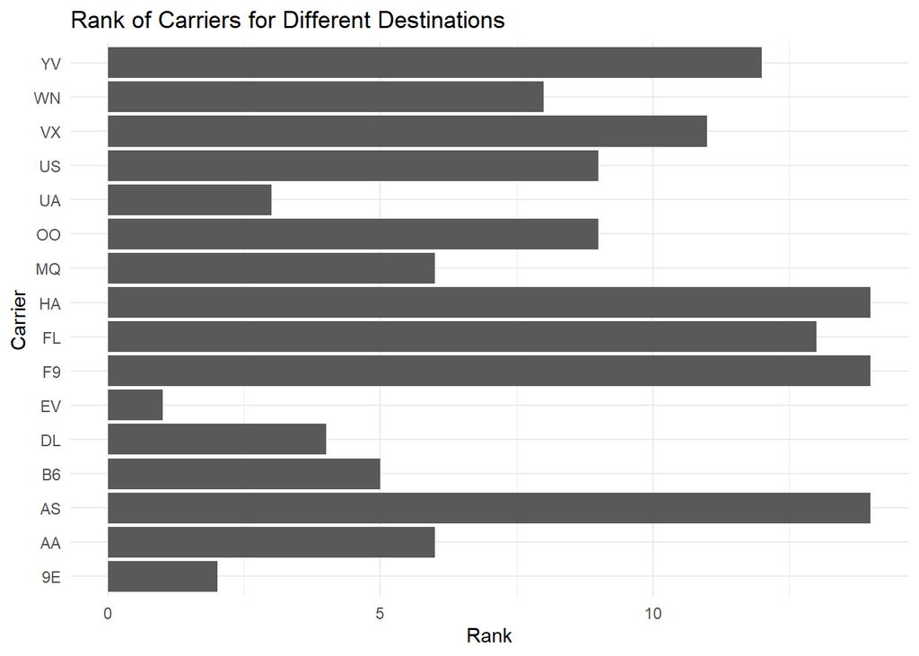

```r
performance_flights <- flights |>
  filter(dest %in% unique(multiple_carriers$dest)) |>
  group_by(carrier) |>
  summarize(n_distinct = n_distinct(dest)) |>
  mutate(rank = min_rank(desc(n_distinct))) |>
  arrange(rank) |>
  ungroup()

performance_flights |>
  ggplot(aes(x = rank, y = carrier)) +
  geom_bar(stat = "identity") +
  labs(title = "Rank of Carriers for Different Destinations",
       x = "Rank",
       y = "Carrier") +
  theme_minimal()
```

```r
# Carrier EV services the most amount of destinations
```

## Transform - Numeric summaries

1. Brainstorm at least 5 different ways to assess the typical delay characteristics of a group of flights. When is mean() useful? When is median() useful? When might you want to use something else? Should you use arrival delay or departure delay? Why might you want to use data from planes?

Mean is useful when the distribution is generally symmetric, median is better when skewed distribution or large outliers.

```r
flights |>
  group_by(tailnum) |>
  mutate(avg_arr_delay = mean(arr_delay, na.rm = TRUE))
```

```
## # A tibble: 336,776 × 20
## # Groups:   tailnum [4,044]
##     year month   day dep_time sched_dep_time dep_delay arr_time sched_arr_time
##    <int> <int> <int>    <int>          <int>     <dbl>    <int>          <int>
##  1  2013     1     1      517            515         2      830            819
##  2  2013     1     1      533            529         4      850            830
##  3  2013     1     1      542            540         2      923            850
##  4  2013     1     1      544            545        -1     1004           1022
##  5  2013     1     1      554            600        -6      812            837
##  6  2013     1     1      554            558        -4      740            728
##  7  2013     1     1      555            600        -5      913            854
##  8  2013     1     1      557            600        -3      709            723
##  9  2013     1     1      557            600        -3      838            846
## 10  2013     1     1      558            600        -2      753            745
## # ℹ 336,766 more rows
## # ℹ 12 more variables: arr_delay <dbl>, carrier <chr>, flight <int>,
## #   tailnum <chr>, origin <chr>, dest <chr>, air_time <dbl>, distance <dbl>,
## #   hour <dbl>, minute <dbl>, time_hour <dttm>, avg_arr_delay <dbl>
```

```r
n_distinct(flights$tailnum)
```

```
## [1] 4044
```

2. Which destinations show the greatest variation in air speed?

If we want to look at variation in air speed we should standardize air speed. The destinations which show the greatest variation in air speed will be those three or more standard deviations above or below the mean.

```r
flights |>
  group_by(dest) |>
  mutate(air_speed = distance / air_time,
         mean_air_speed = mean(air_speed, na.rm = TRUE),
         sd_air_speed = sd(air_speed, na.rm = TRUE),
         std_air_speed = (air_speed - mean_air_speed) / sd_air_speed) |>
  filter(std_air_speed >= mean_air_speed + 3 * sd_air_speed |
         std_air_speed <= mean_air_speed - 3 * sd_air_speed)
```

```
## # A tibble: 327,228 × 23
## # Groups:   dest [103]
##     year month   day dep_time sched_dep_time dep_delay arr_time sched_arr_time
##    <int> <int> <int>    <int>          <int>     <dbl>    <int>          <int>
##  1  2013     1     1      517            515         2      830            819
##  2  2013     1     1      533            529         4      850            830
##  3  2013     1     1      542            540         2      923            850
##  4  2013     1     1      544            545        -1     1004           1022
##  5  2013     1     1      554            600        -6      812            837
##  6  2013     1     1      554            558        -4      740            728
##  7  2013     1     1      555            600        -5      913            854
##  8  2013     1     1      557            600        -3      709            723
##  9  2013     1     1      557            600        -3      838            846
## 10  2013     1     1      558            600        -2      753            745
## # ℹ 327,218 more rows
## # ℹ 15 more variables: arr_delay <dbl>, carrier <chr>, flight <int>,
## #   tailnum <chr>, origin <chr>, dest <chr>, air_time <dbl>, distance <dbl>,
## #   hour <dbl>, minute <dbl>, time_hour <dttm>, air_speed <dbl>,
## #   mean_air_speed <dbl>, sd_air_speed <dbl>, std_air_speed <dbl>
```

```r
# Distribution must clearly be very skewed, lets use IQR method instead
```

```r
flights |>
  mutate(
    air_time_median = median(air_time, na.rm = TRUE),
    air_time_iqr = IQR(air_time, na.rm = TRUE),
    n = n(),
    q999 = quantile(air_time, 0.999, na.rm = TRUE), q001 = quantile(air_time, 0.001, na.rm = TRUE),
    air_time_standard = (air_time - air_time_median) / air_time_iqr
    ) |>
  filter(air_time >= q999 | air_time <= q001) |>
  group_by(dest) |>
  summarize(n = n())
```

```
## # A tibble: 5 × 2
##   dest      n
##   <chr> <int>
## 1 ALB       2
## 2 BDL     251
## 3 BOS       2
## 4 HNL     334
## 5 PHL     104
```

```r
# Destinations ALB, BDL, BOS, HNL and PHL have the largest variations in air_time. ALB and BOS only have a total of two rows each that agree with the above filter statement so they are maybe not that great to include in destinations that have high variation. The other three have counts in the hundreds.
```

3. Create a plot to further explore the adventures of EGE. Can you find any evidence that the airport moved locations? Can you find another variable that might explain the difference?

If the airport moved locations then I imagine we can detect this by looking at the distance column for each origin and destination combination.

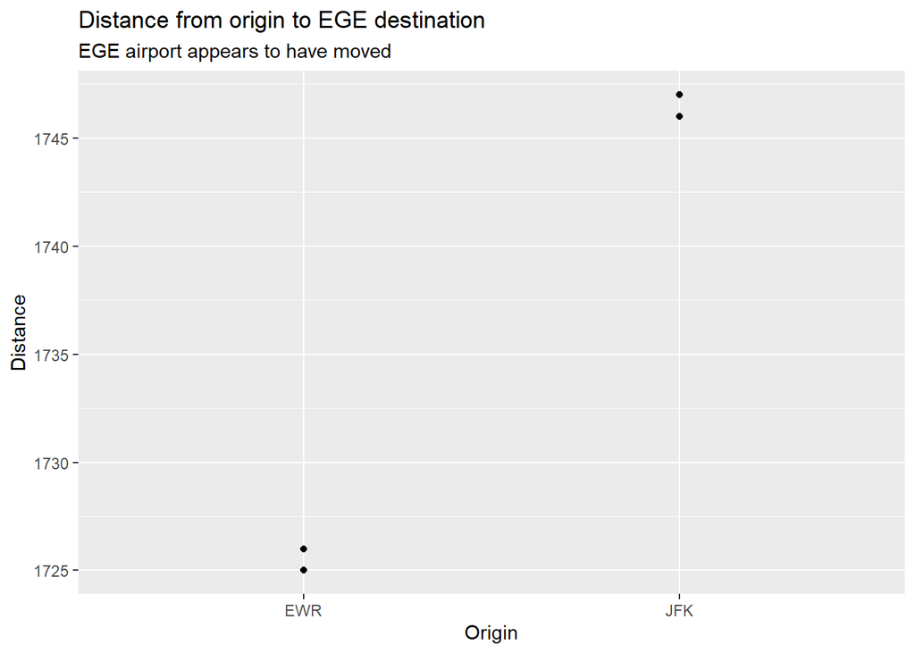

```r
flights_EGE <- flights |>
  filter(dest == "EGE")

View(flights_EGE)

flights_EGE |>
  group_by(origin, dest, distance) |>
  summarize(
    n = n()
  ) |>
  ggplot(aes(origin, distance)) +
  geom_point() +
  labs(
    title = "Distance from origin to EGE destination",
    subtitle = "EGE airport appears to have moved",
    x = "Origin",
    y = "Distance"
  )
```